# Nigerian E-commerce Dataset

## **Context:**

So, in my first Data Analysis Project, I did a simple analysis of the "Nigerian E-commerce Dataset", Data cleansing, transformation, and investigation were all included in this E-Commerce dataset analysis.

## **Libraries needed:**

For this project I will be using three basic libraries:

**Pandas:** for data analysis;

**Numpy:** for data structure and mathematical operations;

**Matplotlib.pyplot:** for data visualization.

```python
import pandas as pd
import numpy as np
import matplotlib.pyplot as plt
```

## **Data import:**

Source: https://www.kaggle.com/datasets/babajidedairo/nigerian-ecommerce-sales-dataset

```python
pd.read_csv(r"C:\Users\pc\Downloads\Copie de Nigerian E-Commerce Dataset.csv")
```

|  | Order ID | Branch Location | Branch Name | Business Name | Is Deleted | Item ID | Item Name | Item Price | Order Item Number | Item Status | Packed Quantity | Quantity | Total Price | Order Date | Order Region | Order Local Area |
| --- | --- | --- | --- | --- | --- | --- | --- | --- | --- | --- | --- | --- | --- | --- | --- | --- |
| 0 | 4672 | Lagos | Generic Store | Generic Stores | FAUX | 60a7b0242498ec1dd380508c | Golden Penny Spaghetti - 500g | 4950.00 | MLPLOCN1FAHUIYK50S0W9YUQ | Cancelled | 1 | 1 | 4950.00 | 5/31/2021 | Lagos | Ifako-Ijaye |
| 1 | 4672 | Lagos | Multipro Consumer Product Limited | MUL | FAUX | 6076c792a6000742949a819c | DANO COOLCOW SACHET - 12X380g | 3392.75 | ML1DN3SZT8R02DKKNKBLXDXA | Cancelled | 2 | 2 | 6785.50 | 5/31/2021 | Lagos | Ifako-Ijaye |
| 2 | 4671 | Lagos | Multipro Consumer Product Limited | MUL | FAUX | 6076c792a6000742949a819c | DANO COOLCOW SACHET - 12X380g | 3392.75 | ML2UMJU6I2P0O958PKZ9AMDQ | Cancelled | 1 | 1 | 3392.75 | 5/31/2021 | Lagos | Ifako-Ijaye |
| 3 | 4670 | Lagos | TDILIFE | TDILIFE | FAUX | 608045d069c51b4e80e70343 | HOLLANDIA EVAP MILK FULL CREAM 60g X 48 | 3370.00 | MLDFDZKVPFV0SHDGGA2KFNRG | Delivered | 1 | 1 | 3370.00 | 5/31/2021 | Lagos | Ifako-Ijaye |
| 4 | 4670 | Lagos | TDILIFE | TDILIFE | FAUX | 608042a469c51b4e80e702f7 | HOLLANDIA EVAP MILK FULL CREAM 190g X 24 | 4845.00 | MLFLBFFM0O5UAS0MROFAL0QA | Cancelled | 1 | 1 | 4845.00 | 5/31/2021 | Lagos | Ifako-Ijaye |
| ... | ... | ... | ... | ... | ... | ... | ... | ... | ... | ... | ... | ... | ... | ... | ... | ... |
| 3923 | 2211 | Lagos | De Majok | De Majok | FAUX | 5fd7ba3a09e73f2f7a58c8ce | Milo 20g | 9200.00 | MLUVQ0APIFXEUZQAZCJXFP0Q | Delivered | 100 | 100 | 920000.00 | 2/1/2021 | Lagos | NaN |
| 3924 | 2211 | Lagos | De Majok | De Majok | FAUX | 5fd7bc7609e73f2f7a58c8e8 | Milo 500g refill | 11200.00 | MLURLOKBJ8DEY2MHC6FCNWBG | Delivered | 30 | 30 | 336000.00 | 2/1/2021 | Lagos | NaN |
| 3925 | 2210 | Lagos | De Majok | De Majok | FAUX | 5fd7ba3a09e73f2f7a58c8ce | Milo 20g | 9200.00 | MLUA5BLCZKCU0C39FXS7GDIA | Delivered | 200 | 200 | 1840000.00 | 2/1/2021 | Lagos | NaN |
| 3926 | 2209 | Lagos | De Majok | De Majok | FAUX | 5fd7c07409e73f2f7a58c910 | Goldenmorn 50g | 7850.00 | MLD7QBQLEGLE0BWKOQXMHTQQ | Delivered | 10 | 10 | 78500.00 | 2/1/2021 | Lagos | NaN |
| 3927 | 2209 | Lagos | Renuzi Ventures | Renuzi Ventures | FAUX | 5fca12e83262da995e0d1a7a | AQUAFINA WATER 75CL | 500.00 | MLNXKSR6UJBUW5JDOHSJHG2W | Delivered | 30 | 30 | 15000.00 | 2/1/2021 | Lagos | NaN |

3928 rows × 16 columns

```python
df = pd.read_csv(r"C:\Users\pc\Downloads\Copie de Nigerian E-Commerce Dataset.csv")
df
```

|  | Order ID | Branch Location | Branch Name | Business Name | Is Deleted | Item ID | Item Name | Item Price | Order Item Number | Item Status | Packed Quantity | Quantity | Total Price | Order Date | Order Region | Order Local Area |
| --- | --- | --- | --- | --- | --- | --- | --- | --- | --- | --- | --- | --- | --- | --- | --- | --- |
| 0 | 4672 | Lagos | Generic Store | Generic Stores | FAUX | 60a7b0242498ec1dd380508c | Golden Penny Spaghetti - 500g | 4950.00 | MLPLOCN1FAHUIYK50S0W9YUQ | Cancelled | 1 | 1 | 4950.00 | 5/31/2021 | Lagos | Ifako-Ijaye |
| 1 | 4672 | Lagos | Multipro Consumer Product Limited | MUL | FAUX | 6076c792a6000742949a819c | DANO COOLCOW SACHET - 12X380g | 3392.75 | ML1DN3SZT8R02DKKNKBLXDXA | Cancelled | 2 | 2 | 6785.50 | 5/31/2021 | Lagos | Ifako-Ijaye |
| 2 | 4671 | Lagos | Multipro Consumer Product Limited | MUL | FAUX | 6076c792a6000742949a819c | DANO COOLCOW SACHET - 12X380g | 3392.75 | ML2UMJU6I2P0O958PKZ9AMDQ | Cancelled | 1 | 1 | 3392.75 | 5/31/2021 | Lagos | Ifako-Ijaye |
| 3 | 4670 | Lagos | TDILIFE | TDILIFE | FAUX | 608045d069c51b4e80e70343 | HOLLANDIA EVAP MILK FULL CREAM 60g X 48 | 3370.00 | MLDFDZKVPFV0SHDGGA2KFNRG | Delivered | 1 | 1 | 3370.00 | 5/31/2021 | Lagos | Ifako-Ijaye |
| 4 | 4670 | Lagos | TDILIFE | TDILIFE | FAUX | 608042a469c51b4e80e702f7 | HOLLANDIA EVAP MILK FULL CREAM 190g X 24 | 4845.00 | MLFLBFFM0O5UAS0MROFAL0QA | Cancelled | 1 | 1 | 4845.00 | 5/31/2021 | Lagos | Ifako-Ijaye |
| ... | ... | ... | ... | ... | ... | ... | ... | ... | ... | ... | ... | ... | ... | ... | ... | ... |
| 3923 | 2211 | Lagos | De Majok | De Majok | FAUX | 5fd7ba3a09e73f2f7a58c8ce | Milo 20g | 9200.00 | MLUVQ0APIFXEUZQAZCJXFP0Q | Delivered | 100 | 100 | 920000.00 | 2/1/2021 | Lagos | NaN |
| 3924 | 2211 | Lagos | De Majok | De Majok | FAUX | 5fd7bc7609e73f2f7a58c8e8 | Milo 500g refill | 11200.00 | MLURLOKBJ8DEY2MHC6FCNWBG | Delivered | 30 | 30 | 336000.00 | 2/1/2021 | Lagos | NaN |
| 3925 | 2210 | Lagos | De Majok | De Majok | FAUX | 5fd7ba3a09e73f2f7a58c8ce | Milo 20g | 9200.00 | MLUA5BLCZKCU0C39FXS7GDIA | Delivered | 200 | 200 | 1840000.00 | 2/1/2021 | Lagos | NaN |
| 3926 | 2209 | Lagos | De Majok | De Majok | FAUX | 5fd7c07409e73f2f7a58c910 | Goldenmorn 50g | 7850.00 | MLD7QBQLEGLE0BWKOQXMHTQQ | Delivered | 10 | 10 | 78500.00 | 2/1/2021 | Lagos | NaN |
| 3927 | 2209 | Lagos | Renuzi Ventures | Renuzi Ventures | FAUX | 5fca12e83262da995e0d1a7a | AQUAFINA WATER 75CL | 500.00 | MLNXKSR6UJBUW5JDOHSJHG2W | Delivered | 30 | 30 | 15000.00 | 2/1/2021 | Lagos | NaN |

3928 rows × 16 columns

## **Data exploration and cleaning:**

```python
df.head(5)
```

[output not shown]

```python
df.tail(5)
```

|  | Order ID | Branch Location | Branch Name | Business Name | Is Deleted | Item ID | Item Name | Item Price | Order Item Number | Item Status | Packed Quantity | Quantity | Total Price | Order Date | Order Region | Order Local Area |
| --- | --- | --- | --- | --- | --- | --- | --- | --- | --- | --- | --- | --- | --- | --- | --- | --- |
| 3923 | 2211 | Lagos | De Majok | De Majok | FAUX | 5fd7ba3a09e73f2f7a58c8ce | Milo 20g | 9200.0 | MLUVQ0APIFXEUZQAZCJXFP0Q | Delivered | 100 | 100 | 920000.0 | 2/1/2021 | Lagos | NaN |
| 3924 | 2211 | Lagos | De Majok | De Majok | FAUX | 5fd7bc7609e73f2f7a58c8e8 | Milo 500g refill | 11200.0 | MLURLOKBJ8DEY2MHC6FCNWBG | Delivered | 30 | 30 | 336000.0 | 2/1/2021 | Lagos | NaN |
| 3925 | 2210 | Lagos | De Majok | De Majok | FAUX | 5fd7ba3a09e73f2f7a58c8ce | Milo 20g | 9200.0 | MLUA5BLCZKCU0C39FXS7GDIA | Delivered | 200 | 200 | 1840000.0 | 2/1/2021 | Lagos | NaN |
| 3926 | 2209 | Lagos | De Majok | De Majok | FAUX | 5fd7c07409e73f2f7a58c910 | Goldenmorn 50g | 7850.0 | MLD7QBQLEGLE0BWKOQXMHTQQ | Delivered | 10 | 10 | 78500.0 | 2/1/2021 | Lagos | NaN |
| 3927 | 2209 | Lagos | Renuzi Ventures | Renuzi Ventures | FAUX | 5fca12e83262da995e0d1a7a | AQUAFINA WATER 75CL | 500.0 | MLNXKSR6UJBUW5JDOHSJHG2W | Delivered | 30 | 30 | 15000.0 | 2/1/2021 | Lagos | NaN |

```python
df.info()
```

```
<class 'pandas.core.frame.DataFrame'>
RangeIndex: 3928 entries, 0 to 3927
Data columns (total 16 columns):
 #   Column             Non-Null Count  Dtype
---  ------             --------------  -----
 0   Order ID           3928 non-null   int64
 1   Branch Location    3928 non-null   object
 2   Branch Name        3928 non-null   object
 3   Business Name      3928 non-null   object
 4   Is Deleted         3928 non-null   object
 5   Item ID            3928 non-null   object
 6   Item Name          3928 non-null   object
 7   Item Price         3928 non-null   float64
 8   Order Item Number  3928 non-null   object
 9   Item Status        3928 non-null   object
 10  Packed Quantity    3928 non-null   int64
 11  Quantity           3928 non-null   int64
 12  Total Price        3928 non-null   float64
 13  Order Date         3928 non-null   object
 14  Order Region       3771 non-null   object
 15  Order Local Area   3056 non-null   object
dtypes: float64(2), int64(3), object(11)
memory usage: 491.1+ KB
```

Order ID is shown as an int64, it's not used for math, it’s just a unique identifier, like a name tag. So it makes more sense to treat it as a string (object)

```python
df['Order ID'] = df['Order ID'].astype(str)
df.info()
```

```
<class 'pandas.core.frame.DataFrame'>
RangeIndex: 3928 entries, 0 to 3927
Data columns (total 16 columns):
 #   Column             Non-Null Count  Dtype
---  ------             --------------  -----
 0   Order ID           3928 non-null   object
 1   Branch Location    3928 non-null   object
 2   Branch Name        3928 non-null   object
 3   Business Name      3928 non-null   object
 4   Is Deleted         3928 non-null   object
 5   Item ID            3928 non-null   object
 6   Item Name          3928 non-null   object
 7   Item Price         3928 non-null   float64
 8   Order Item Number  3928 non-null   object
 9   Item Status        3928 non-null   object
 10  Packed Quantity    3928 non-null   int64
 11  Quantity           3928 non-null   int64
 12  Total Price        3928 non-null   float64
 13  Order Date         3928 non-null   object
 14  Order Region       3771 non-null   object
 15  Order Local Area   3056 non-null   object
dtypes: float64(2), int64(2), object(12)
memory usage: 491.1+ KB
```

Now I change the date format of the 'Order Date' column so python recognizes it as a date

```python
df['Order Date'] = pd.to_datetime(df['Order Date'], format='%m/%d/%Y')
```

What period of time is our data in?

```python
print("Date of earliest entry: ",df['Order Date'].min())
print("Date of latest entry: ",df['Order Date'].max())
```

```
Date of earliest entry:  2021-02-01 00:00:00
Date of latest entry:  2021-05-31 00:00:00
```

How many 'Branch Location' is there in our Data?

```python
len(df['Branch Location'].unique())
```

```
3
```

Is there any null values?

```python
df[df.columns[df.isnull().any()]]
```

|  | Order Region | Order Local Area |
| --- | --- | --- |
| 0 | Lagos | Ifako-Ijaye |
| 1 | Lagos | Ifako-Ijaye |
| 2 | Lagos | Ifako-Ijaye |
| 3 | Lagos | Ifako-Ijaye |
| 4 | Lagos | Ifako-Ijaye |
| ... | ... | ... |
| 3923 | Lagos | NaN |
| 3924 | Lagos | NaN |
| 3925 | Lagos | NaN |
| 3926 | Lagos | NaN |
| 3927 | Lagos | NaN |

3928 rows × 2 columns

Let’s check again what columns have missing values and how many:

```python
df.isnull().sum()
```

```
Order ID               0
Branch Location        0
Branch Name            0
Business Name          0
Is Deleted             0
Item ID                0
Item Name              0
Item Price             0
Order Item Number      0
Item Status            0
Packed Quantity        0
Quantity               0
Total Price            0
Order Date             0
Order Region         157
Order Local Area     872
dtype: int64
```

```python
df.dropna(subset=['Order Region', 'Order Local Area'], inplace=True)
df
```

|  | Order ID | Branch Location | Branch Name | Business Name | Is Deleted | Item ID | Item Name | Item Price | Order Item Number | Item Status | Packed Quantity | Quantity | Total Price | Order Date | Order Region | Order Local Area |
| --- | --- | --- | --- | --- | --- | --- | --- | --- | --- | --- | --- | --- | --- | --- | --- | --- |
| 0 | 4672 | Lagos | Generic Store | Generic Stores | FAUX | 60a7b0242498ec1dd380508c | Golden Penny Spaghetti - 500g | 4950.00 | MLPLOCN1FAHUIYK50S0W9YUQ | Cancelled | 1 | 1 | 4950.00 | 2021-05-31 | Lagos | Ifako-Ijaye |
| 1 | 4672 | Lagos | Multipro Consumer Product Limited | MUL | FAUX | 6076c792a6000742949a819c | DANO COOLCOW SACHET - 12X380g | 3392.75 | ML1DN3SZT8R02DKKNKBLXDXA | Cancelled | 2 | 2 | 6785.50 | 2021-05-31 | Lagos | Ifako-Ijaye |
| 2 | 4671 | Lagos | Multipro Consumer Product Limited | MUL | FAUX | 6076c792a6000742949a819c | DANO COOLCOW SACHET - 12X380g | 3392.75 | ML2UMJU6I2P0O958PKZ9AMDQ | Cancelled | 1 | 1 | 3392.75 | 2021-05-31 | Lagos | Ifako-Ijaye |
| 3 | 4670 | Lagos | TDILIFE | TDILIFE | FAUX | 608045d069c51b4e80e70343 | HOLLANDIA EVAP MILK FULL CREAM 60g X 48 | 3370.00 | MLDFDZKVPFV0SHDGGA2KFNRG | Delivered | 1 | 1 | 3370.00 | 2021-05-31 | Lagos | Ifako-Ijaye |
| 4 | 4670 | Lagos | TDILIFE | TDILIFE | FAUX | 608042a469c51b4e80e702f7 | HOLLANDIA EVAP MILK FULL CREAM 190g X 24 | 4845.00 | MLFLBFFM0O5UAS0MROFAL0QA | Cancelled | 1 | 1 | 4845.00 | 2021-05-31 | Lagos | Ifako-Ijaye |
| ... | ... | ... | ... | ... | ... | ... | ... | ... | ... | ... | ... | ... | ... | ... | ... | ... |
| 3208 | 2502 | Lagos | Tripple P Dazzled | Tripple P Dazzled | FAUX | 600fd22909e73f2f7a5978cf | Golden Morn 900g | 7841.00 | MLG600EA0U6KGGUES4MFEKCG | Cancelled | 1 | 1 | 7841.00 | 2021-03-25 | Oyo | Mushin |
| 3209 | 2501 | Lagos | Tripple P Dazzled | Tripple P Dazzled | FAUX | 60110fab09e73f2f7a597edb | NESTLE MILO READY TO DRINK 180ML | 1076.00 | MLCFRTNWVI700Y9U5EA0J8NQ | Cancelled | 1 | 1 | 1076.00 | 2021-03-25 | Lagos | Surulere |
| 3210 | 2500 | Lagos | Tripple P Dazzled | Tripple P Dazzled | FAUX | 600ecba709e73f2f7a59768b | Milo 20g | 9000.00 | ML1S7HBS80ZKG3W40OKGBIAW | Cancelled | 1 | 1 | 9000.00 | 2021-03-25 | Lagos | Surulere |
| 3211 | 2500 | Lagos | Tripple P Dazzled | Tripple P Dazzled | FAUX | 600fcac309e73f2f7a5978c0 | NESTLE GOLDEN MORN 50G | 7850.00 | MLSCKKU2RWAUSWXBAM6HNJKG | Cancelled | 1 | 1 | 7850.00 | 2021-03-25 | Lagos | Surulere |
| 3212 | 2500 | Lagos | Deeski Store Limited | Deeski Store Limited | FAUX | 602cd2e409e73f2f7a59c192 | Nasco Cornflakes 30g | 2000.00 | MLNTYHXC70B069UVQSXYPF0G | Delivered | 1 | 1 | 2000.00 | 2021-03-25 | Lagos | Ibeju-Lekki |

2899 rows × 16 columns

Then let's check how many duplicate rows are in your dataset?

```python
df.duplicated().sum()
```

```
np.int64(0)
```

The above result means that there are no duplicate rows in our DataFrame.

```python
df.describe()
```

|  | Item Price | Packed Quantity | Quantity | Total Price | Order Date |
| --- | --- | --- | --- | --- | --- |
| count | 2899.000000 | 2899.000000 | 2899.000000 | 2.899000e+03 | 2899 |
| mean | 7333.418504 | 49.654709 | 49.654709 | 4.100717e+05 | 2021-05-04 20:24:25.332873472 |
| min | 0.000000 | 1.000000 | 1.000000 | 0.000000e+00 | 2021-03-25 00:00:00 |
| 25% | 3150.000000 | 1.000000 | 1.000000 | 8.200000e+03 | 2021-04-22 00:00:00 |
| 50% | 7790.000000 | 5.000000 | 5.000000 | 1.998750e+04 | 2021-05-10 00:00:00 |
| 75% | 9300.000000 | 20.000000 | 20.000000 | 9.170000e+04 | 2021-05-21 00:00:00 |
| max | 485000.000000 | 8306.000000 | 8306.000000 | 7.599990e+07 | 2021-05-31 00:00:00 |
| std | 15258.219137 | 252.365597 | 252.365597 | 2.243405e+06 | NaN |

Let's do some Filtering:

```python
high_price_items = df[df['Item Price'] > 100000]
high_price_items
```

|  | Order ID | Branch Location | Branch Name | Business Name | Is Deleted | Item ID | Item Name | Item Price | Order Item Number | Item Status | Packed Quantity | Quantity | Total Price | Order Date | Order Region | Order Local Area |
| --- | --- | --- | --- | --- | --- | --- | --- | --- | --- | --- | --- | --- | --- | --- | --- | --- |
| 15 | 4665 | Lagos | Farmer First | Farmer First | FAUX | 6066180969c51b4e80e6f423 | Cashew Nut | 485000.0 | MLCMJJ1V1WSUMHLHQAFDNMOW | Delivered | 30 | 30 | 14550000.0 | 2021-05-31 | Lagos | Oshodi-Isolo |
| 2630 | 2791 | Lagos | Farmer First | Farmer First | FAUX | 6066180969c51b4e80e6f423 | Cashew Nut | 443700.0 | ML0UYPHLTAOKYIJ6QXMJKNWW | Cancelled | 60 | 60 | 26622000.0 | 2021-04-16 | Lagos | Oshodi-Isolo |
| 2845 | 2633 | Lagos | OneKioskAfrica | OneKioskAfrica | FAUX | 606dcbbb69c51b4e80e6f76c | Cashew Nut | 418200.0 | ML10YEYUFLSUMTB5NGEWNTFG | Delivered | 30 | 30 | 12546000.0 | 2021-04-07 | Lagos | Oshodi-Isolo |
| 2912 | 2604 | Lagos | Renuzi Ventures | Renuzi Ventures | FAUX | 606c372469c51b4e80e6f63b | Supa Kommando Energy Drink | 107625.0 | ML1SB76ENCQEGZYTSW8ZKYHA | Cancelled | 3 | 3 | 322875.0 | 2021-04-06 | Lagos | Mushin |

```python
high_quantity_orders = df[df['Quantity'] > 2000]
high_quantity_orders
```

|  | Order ID | Branch Location | Branch Name | Business Name | Is Deleted | Item ID | Item Name | Item Price | Order Item Number | Item Status | Packed Quantity | Quantity | Total Price | Order Date | Order Region | Order Local Area |
| --- | --- | --- | --- | --- | --- | --- | --- | --- | --- | --- | --- | --- | --- | --- | --- | --- |
| 107 | 4595 | Lagos | Tripple P Dazzled | Tripple P Dazzled | FAUX | 60ab84412498ec1dd38050f5 | Milo Refill Pack - 450g | 11200.0 | MLA0AGTZV0K020ONY1F8WKVG | Delivered | 2400 | 2400 | 26880000.0 | 2021-05-28 | Lagos | Oshodi-Isolo |
| 326 | 4406 | Lagos | RSL International Limited | RSL International Limited | FAUX | 60ae8fe4de580f555576d1c3 | MILO - 240x20g | 9100.0 | MLO85P0HLAYUI6GSR7I9NETW | Delivered | 2500 | 2500 | 22750000.0 | 2021-05-26 | Lagos | Oshodi-Isolo |
| 327 | 4405 | Lagos | RSL International Limited | RSL International Limited | FAUX | 60ae8fe4de580f555576d1c3 | MILO - 240x20g | 9100.0 | MLDNTTVOMT0KMR6E5P0IYFZA | Delivered | 3000 | 3000 | 27300000.0 | 2021-05-26 | Lagos | Oshodi-Isolo |
| 2243 | 3079 | Lagos | Tripple P Dazzled | Tripple P Dazzled | FAUX | 606c7b1069c51b4e80e6f6a0 | Milo Sachet 20g | 9150.0 | MLE0KEYZ0O8US0E2KGLPSKVG | Delivered | 8306 | 8306 | 75999900.0 | 2021-04-30 | Lagos | Ado-Odo/Ota |
| 2660 | 2768 | Lagos | Renuzi Ventures | Renuzi Ventures | FAUX | 5fcf9cc73262da995e0d1a9a | SUNLIGHT POWDER DESTINY YELLOW FIBRITES 2kG | 5500.0 | MLB5R2C6BCUEYVFO5S4Z918Q | Delivered | 2182 | 2182 | 12001000.0 | 2021-04-14 | Lagos | Abeokuta South |
| 3105 | 2539 | Lagos | Mercy & Honey Ventures | Mercy & Honey Ventures | FAUX | 604a2127f77d7250766fed68 | 3CROWNS EVAPORATED -TIN 24 X 160g | 4000.0 | ML45ZNWAJUGE6FYXMINHEPQA | Delivered | 5000 | 5000 | 20000000.0 | 2021-03-29 | Lagos | Alimosho |
| 3124 | 2523 | Lagos | Deeski Store Limited | Deeski Store Limited | FAUX | 602cd2e409e73f2f7a59c192 | Nasco Cornflakes 30g | 2000.0 | MLVYI06C5FSUCVWKDVR143KW | Delivered | 3000 | 3000 | 6000000.0 | 2021-03-26 | Lagos | Alimosho |

```python
recent_orders = df[df['Order Date'] > '2021-05-01']
recent_orders
```

|  | Order ID | Branch Location | Branch Name | Business Name | Is Deleted | Item ID | Item Name | Item Price | Order Item Number | Item Status | Packed Quantity | Quantity | Total Price | Order Date | Order Region | Order Local Area |
| --- | --- | --- | --- | --- | --- | --- | --- | --- | --- | --- | --- | --- | --- | --- | --- | --- |
| 0 | 4672 | Lagos | Generic Store | Generic Stores | FAUX | 60a7b0242498ec1dd380508c | Golden Penny Spaghetti - 500g | 4950.00 | MLPLOCN1FAHUIYK50S0W9YUQ | Cancelled | 1 | 1 | 4950.00 | 2021-05-31 | Lagos | Ifako-Ijaye |
| 1 | 4672 | Lagos | Multipro Consumer Product Limited | MUL | FAUX | 6076c792a6000742949a819c | DANO COOLCOW SACHET - 12X380g | 3392.75 | ML1DN3SZT8R02DKKNKBLXDXA | Cancelled | 2 | 2 | 6785.50 | 2021-05-31 | Lagos | Ifako-Ijaye |
| 2 | 4671 | Lagos | Multipro Consumer Product Limited | MUL | FAUX | 6076c792a6000742949a819c | DANO COOLCOW SACHET - 12X380g | 3392.75 | ML2UMJU6I2P0O958PKZ9AMDQ | Cancelled | 1 | 1 | 3392.75 | 2021-05-31 | Lagos | Ifako-Ijaye |
| 3 | 4670 | Lagos | TDILIFE | TDILIFE | FAUX | 608045d069c51b4e80e70343 | HOLLANDIA EVAP MILK FULL CREAM 60g X 48 | 3370.00 | MLDFDZKVPFV0SHDGGA2KFNRG | Delivered | 1 | 1 | 3370.00 | 2021-05-31 | Lagos | Ifako-Ijaye |
| 4 | 4670 | Lagos | TDILIFE | TDILIFE | FAUX | 608042a469c51b4e80e702f7 | HOLLANDIA EVAP MILK FULL CREAM 190g X 24 | 4845.00 | MLFLBFFM0O5UAS0MROFAL0QA | Cancelled | 1 | 1 | 4845.00 | 2021-05-31 | Lagos | Ifako-Ijaye |
| ... | ... | ... | ... | ... | ... | ... | ... | ... | ... | ... | ... | ... | ... | ... | ... | ... |
| 2183 | 3130 | Lagos | Renuzi Ventures | Renuzi Ventures | FAUX | 5fcf9cc73262da995e0d1a9a | SUNLIGHT POWDER DESTINY YELLOW FIBRITES - 2kG | 5500.00 | ML0LZMXCTGJ00VNCASORBHGW | Delivered | 50 | 50 | 275000.00 | 2021-05-03 | Lagos | Kosofe |
| 2184 | 3129 | Lagos | Tripple P Dazzled | Tripple P Dazzled | FAUX | 606da1db69c51b4e80e6f71d | Golden Morn 900g | 7892.50 | MLBU0KWAIPJUWP0UNL0690YG | Delivered | 10 | 10 | 78925.00 | 2021-05-03 | Lagos | Kosofe |
| 2185 | 3129 | Lagos | Tripple P Dazzled | Tripple P Dazzled | FAUX | 606463a669c51b4e80e6f3c6 | MILO 5OOG REFILL | 11378.00 | MLXPVZQJFDE0A1ZD0L3D8VWQ | Delivered | 5 | 5 | 56890.00 | 2021-05-03 | Lagos | Kosofe |
| 2186 | 3129 | Lagos | Tripple P Dazzled | Tripple P Dazzled | FAUX | 606da0e469c51b4e80e6f71a | Milo Energy Cubes 2.7g | 15682.50 | MLLJGZA1NMXUACJXRX0PGFOQ | Cancelled | 5 | 5 | 78412.50 | 2021-05-03 | Lagos | Kosofe |
| 2187 | 3128 | Lagos | Renuzi Ventures | Renuzi Ventures | FAUX | 6017191e09e73f2f7a598bd8 | Knorr Chicken 17x50x8g | 9450.00 | MLGKYCRTG41KG4M8QXHD4HCG | Delivered | 50 | 50 | 472500.00 | 2021-05-02 | Lagos | Kosofe |

1874 rows × 16 columns

```python
df[(df['Item Status'] == 'Delivered') & (df['Order Date'] == '2021-05-03')]
```

|  | Order ID | Branch Location | Branch Name | Business Name | Is Deleted | Item ID | Item Name | Item Price | Order Item Number | Item Status | Packed Quantity | Quantity | Total Price | Order Date | Order Region | Order Local Area |
| --- | --- | --- | --- | --- | --- | --- | --- | --- | --- | --- | --- | --- | --- | --- | --- | --- |
| 2173 | 3135 | Lagos | Tripple P Dazzled | Tripple P Dazzled | FAUX | 606da01169c51b4e80e6f718 | Milo RTD 180ml | 1332.50 | MLFTTYIQBXTKUTGZ0JDW0OXW | Delivered | 1 | 1 | 1332.5 | 2021-05-03 | Lagos | Kosofe |
| 2174 | 3134 | Lagos | Ecopeaks Limited | Ecopeaks Limited | FAUX | 606df41669c51b4e80e6f7ba | GOLDEN PENNY SEMOVITA 10KG | 3793.00 | MLKLG2XLE5HEA77TGVJWZGAW | Delivered | 1 | 1 | 3793.0 | 2021-05-03 | Lagos | Kosofe |
| 2175 | 3134 | Lagos | Deeski Store Limited | Deeski Store Limited | FAUX | 6080461e69c51b4e80e7034f | HOLLANDIA EVAP MILK FULL CREAM - 60g X 48 | 3370.00 | MLIZTNET0WVUMDCFLK26OGIA | Delivered | 1 | 1 | 3370.0 | 2021-05-03 | Lagos | Kosofe |
| 2176 | 3134 | Lagos | TDILIFE | TDILIFE | FAUX | 608043c969c51b4e80e70314 | HOLLANDIA EVAP MILK FULL CREAM 120g X 24 | 2760.00 | MLKEUOFYSWAKMILRTI800YGG | Delivered | 1 | 1 | 2760.0 | 2021-05-03 | Lagos | Kosofe |
| 2177 | 3133 | Lagos | Multipro Consumer Product Limited | MUL | FAUX | 6076c792a6000742949a814e | INDOMIE CHICKEN HUNGRYMAN - 24 X 180GMS | 3628.50 | MLQDUVRETAGUEMA6IH0O7VFA | Delivered | 1 | 1 | 3628.5 | 2021-05-03 | Lagos | Kosofe |
| 2178 | 3133 | Lagos | Ecopeaks Limited | Ecopeaks Limited | FAUX | 6008646609e73f2f7a595e3a | Golden Penny Spaghetti | 4766.00 | MLH7FMSU8XMKYFCTS30APR3G | Delivered | 2 | 2 | 9532.0 | 2021-05-03 | Lagos | Kosofe |
| 2180 | 3132 | Lagos | Multipro Consumer Product Limited | MUL | FAUX | 6076c792a6000742949a8158 | DANO COOLCOW SACHET - 260 X 12G | 8508.00 | MLQW39RWY0UKCIXHVRXP7PYW | Delivered | 1 | 1 | 8508.0 | 2021-05-03 | Lagos | Kosofe |
| 2181 | 3131 | Lagos | Multipro Consumer Product Limited | MUL | FAUX | 6076c792a6000742949a814c | INDOMIE REGULAR CHICKEN - 70gx40 | 2306.25 | MLDYWHIPALG0KV79HAFLPA8W | Delivered | 2 | 2 | 4612.5 | 2021-05-03 | Lagos | Kosofe |
| 2182 | 3131 | Lagos | TDILIFE | TDILIFE | FAUX | 6079a165a6000742949a8299 | Cowbell Choco Sachet - 22.5g (10x 25) | 7995.00 | MLGURFGMC6C0A3WH0BWRRX5G | Delivered | 1 | 1 | 7995.0 | 2021-05-03 | Lagos | Kosofe |
| 2183 | 3130 | Lagos | Renuzi Ventures | Renuzi Ventures | FAUX | 5fcf9cc73262da995e0d1a9a | SUNLIGHT POWDER DESTINY YELLOW FIBRITES - 2kG | 5500.00 | ML0LZMXCTGJ00VNCASORBHGW | Delivered | 50 | 50 | 275000.0 | 2021-05-03 | Lagos | Kosofe |
| 2184 | 3129 | Lagos | Tripple P Dazzled | Tripple P Dazzled | FAUX | 606da1db69c51b4e80e6f71d | Golden Morn 900g | 7892.50 | MLBU0KWAIPJUWP0UNL0690YG | Delivered | 10 | 10 | 78925.0 | 2021-05-03 | Lagos | Kosofe |
| 2185 | 3129 | Lagos | Tripple P Dazzled | Tripple P Dazzled | FAUX | 606463a669c51b4e80e6f3c6 | MILO 5OOG REFILL | 11378.00 | MLXPVZQJFDE0A1ZD0L3D8VWQ | Delivered | 5 | 5 | 56890.0 | 2021-05-03 | Lagos | Kosofe |

Time to visualize:

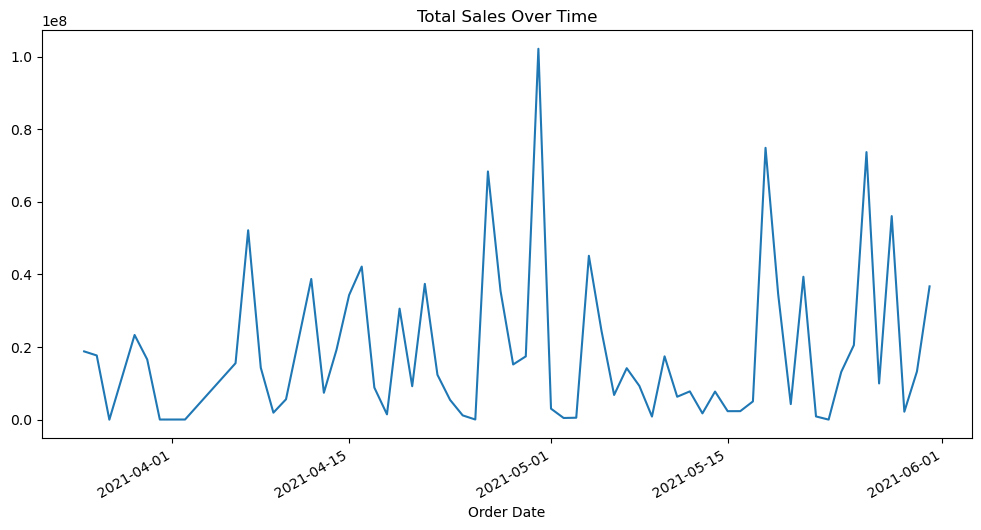

```python
daily_sales = df.groupby('Order Date')['Total Price'].sum()
daily_sales.plot(kind='line', figsize=(12, 6), title='Total Sales Over Time')
```

```
Item Name
Milo Sachet 20g                      240261355.0
Knorr Chicken 17x50x8g               108702324.0
Maize                                 92569000.0
Close Up Ever Fresh Red Hot 140g      70625978.0
MILO - 240x20g                        63700000.0
Milo Refill Pack - 450g               61213350.0
3CROWNS EVAPORATED -TIN 24 X 160g     44204220.0
Cashew Nut                            41172000.0
NESTLE GOLDEN MORN 50G                41019496.0
Big Bull Rice - 50kg                  25000000.0
Name: Total Price, dtype: float64
```

[figure not shown]

```python
top_items = df.groupby('Item Name')['Total Price'].sum().sort_values(ascending=False).head(10)
print(top_items)
top_items.plot(kind= 'bar', figsize=(12, 6), title='Top 10 Products Quantity Sold')
```

```python
branch_sales = df.groupby('Branch Name')['Total Price'].sum().sort_values(ascending=False)
print(branch_sales)
```

```
Branch Name
Tripple P Dazzled                          3.755210e+08
Renuzi Ventures                            3.306892e+08
Farmer First                               1.359654e+08
Mercy & Honey Ventures                     9.353356e+07
Deeski Store Limited                       7.814518e+07
RSL International Limited                  6.370000e+07
Ecopeaks Limited                           4.119341e+07
Marzab Multiventures                       3.130930e+07
TDILIFE                                    1.639994e+07
OneKioskAfrica                             1.254600e+07
Generic Store                              4.449291e+06
Multipro Consumer Product Limited          2.429793e+06
Multiventures                              1.306250e+06
Stella olasebikan Trading Stores           1.184980e+06
Femadon Stores Ltd                         1.927000e+05
Product Plug                               1.487300e+05
Extreme Manufacturing Nigeria limited      3.068000e+04
TSQALAYO and sons                          2.700000e+04
Funky stores Nigeria LTD.                  1.450500e+04
Ekulo International Limited(Wine world)    9.491500e+03
Toyo mart                                  1.350000e+03
Name: Total Price, dtype: float64
```